# R筆記–(3)套件與函式

skydome20

2016/03/14

[返回主目錄](https://rpubs.com/skydome20/Table)

# 本篇目錄

1. 函式(function)
   - Summarize函式
   - 敘述統計函式
   - 其他實用函式
     - 串接：paste(), append()
     - 合併：rbind(), cbind()
     - 數列：sample(), seq()
     - 預覽：head(), tail()
     - 排序：order(), sort()
     - 重複：unique(), duplicated()
     - which()
2. 套件(package)
   - 安裝套件
     - 方法一：用RStudio介面
     - 方法二：用install.packages()
   - 匯入套件
3. 總結
4. (額外) Happy White Day

相信現在大家對[R語言的資料型態](https://rpubs.com/skydome20/R-Note2-dataType) 有一定程度的熟悉。  
但在R語言中只是第一步。若要熟練地處理/分析資料，必須要掌握另一個技巧：  
**套件(package)與函式(function)。**

沒有寫過程式的人，可能對函式(function)不是那麼熟悉，但其實理解起來並不難。  
還記得國中的數學課，有一個章節叫「代數與函數」嗎？  
我們可能會根據某一道題目，建立一個f(x)=2x+3的式子對吧？這裡的f(x)，就是「函式」(函數)。  
函式之所以好用，就是因為裡面已經幫你制定好規則。  
因此，即使把不同的情況(x=2, x=3)丟入，也會根據相同的規則(f(x)=2x+3)，產出結果(f(x=2)=7, f(x=3)=9)。

由於R是一個Open Source的程式語言(簡單來說，全世界的人在R語言上進行開發，撰寫自己的函式)，因此具有豐沛的函式集，也就是「套件」(package)。

以下將會介紹R裡面一些實用的函式，以及如何根據自己的需求，搜尋到對應的套件並安裝。

# **1. 函式(function)**

## Summarize函式

如果還記得的話，其實在上一篇的[文章](https://rpubs.com/skydome20/R-Note2-dataType)中，已經介紹過許多函式(`is.integer()`, `data frame()`, `c()`, `str()`…)  
其中，`str()`十分好用，尤其在了解一筆資料時或未知的變數時，能派上很大的用場。  
除此之外，還有一個相當強大、具有類似功能的函式，叫做`summary()`。  
我們先拿R內建的鳶尾花資料(iris)，比較看看`str()`和`summary()`的功用吧：

```r
str(iris)
```

```
## 'data.frame':    150 obs. of  5 variables:
##  $ Sepal.Length: num  5.1 4.9 4.7 4.6 5 5.4 4.6 5 4.4 4.9 ...
##  $ Sepal.Width : num  3.5 3 3.2 3.1 3.6 3.9 3.4 3.4 2.9 3.1 ...
##  $ Petal.Length: num  1.4 1.4 1.3 1.5 1.4 1.7 1.4 1.5 1.4 1.5 ...
##  $ Petal.Width : num  0.2 0.2 0.2 0.2 0.2 0.4 0.3 0.2 0.2 0.1 ...
##  $ Species     : Factor w/ 3 levels "setosa","versicolor",..: 1 1 1 1 1 1 1 1 1 1 ...
```

```r
summary(iris)
```

```
##   Sepal.Length    Sepal.Width     Petal.Length    Petal.Width
##  Min.   :4.300   Min.   :2.000   Min.   :1.000   Min.   :0.100
##  1st Qu.:5.100   1st Qu.:2.800   1st Qu.:1.600   1st Qu.:0.300
##  Median :5.800   Median :3.000   Median :4.350   Median :1.300
##  Mean   :5.843   Mean   :3.057   Mean   :3.758   Mean   :1.199
##  3rd Qu.:6.400   3rd Qu.:3.300   3rd Qu.:5.100   3rd Qu.:1.800
##  Max.   :7.900   Max.   :4.400   Max.   :6.900   Max.   :2.500
##        Species
##  setosa    :50
##  versicolor:50
##  virginica :50
##
##
##
```

你會發現，`str()`列出資料內每個欄位的狀態，  
而`summary()`則給出每個欄位的「最大值」、「最小值」、「平均值」、「中位數」「第一四分位數」…等等。  
那麼，`str()`和`summary()`的差別究竟在哪裡呢？  
這裡要教一個實用的小技巧：**當你不清楚「一個函式的用途」、「該如何使用」時，要從哪裡找到說明文件(Help)？**  
答案很簡單！請在console裡面，輸入`?str`和`?summary`指令(如下圖)：

[figure not shown]

你會發現，在右手邊的「Help」欄位，會出現說明文件，裡面包括「函式的套件」、「函式的用途」、「參數說明」、「使用上的教學示範」…  
這個技巧，在日後會時常用到！  
**(重要觀念：當接觸一個新的函式時，第一步就是要去了解「它的用途」、以及「如何去使用」！)**

(小練習)請試著在console裡，查詢`summary()`的說明文件

## 敘述統計函式

敘述統計是進行資料分析時，有效瀏覽(explore)、了解(recognize)資料狀態的步驟。  
作為一個資料分析軟體，R裡面自然有許多可以協助我們進行敘述統計分析的函式：

- `mean()`：平均值
- `var()`：變異數
- `sd()`：標準差
- `median()`：中位數
- `max()`：最大值
- `min()`：最小值
- `sum()`：綜合相加
- `quantile()`：分位數
- `range()`：全距

對鳶尾花資料(iris)進行簡單的示範：

```r
# 從iris的資料集中，取"Sepal.Length"(花萼長度)這個欄位的資料出來(利用神奇符號$)
iris$Sepal.Length
```

```
##   [1] 5.1 4.9 4.7 4.6 5.0 5.4 4.6 5.0 4.4 4.9 5.4 4.8 4.8 4.3 5.8 5.7 5.4
##  [18] 5.1 5.7 5.1 5.4 5.1 4.6 5.1 4.8 5.0 5.0 5.2 5.2 4.7 4.8 5.4 5.2 5.5
##  [35] 4.9 5.0 5.5 4.9 4.4 5.1 5.0 4.5 4.4 5.0 5.1 4.8 5.1 4.6 5.3 5.0 7.0
##  [52] 6.4 6.9 5.5 6.5 5.7 6.3 4.9 6.6 5.2 5.0 5.9 6.0 6.1 5.6 6.7 5.6 5.8
##  [69] 6.2 5.6 5.9 6.1 6.3 6.1 6.4 6.6 6.8 6.7 6.0 5.7 5.5 5.5 5.8 6.0 5.4
##  [86] 6.0 6.7 6.3 5.6 5.5 5.5 6.1 5.8 5.0 5.6 5.7 5.7 6.2 5.1 5.7 6.3 5.8
## [103] 7.1 6.3 6.5 7.6 4.9 7.3 6.7 7.2 6.5 6.4 6.8 5.7 5.8 6.4 6.5 7.7 7.7
## [120] 6.0 6.9 5.6 7.7 6.3 6.7 7.2 6.2 6.1 6.4 7.2 7.4 7.9 6.4 6.3 6.1 7.7
## [137] 6.3 6.4 6.0 6.9 6.7 6.9 5.8 6.8 6.7 6.7 6.3 6.5 6.2 5.9
```

發現到了嗎？從data frame裡面取出來的「某一欄」資料，就是一個陣列(vector)的形式。(代表每一筆觀測值的花萼長度)  
現在，就把上面這些函式，應用到這個陣列資料上吧(雖然有點無聊XD)：

```r
mean(iris$Sepal.Length)     #「花萼長度」的平均值
var(iris$Sepal.Length)      #「花萼長度」的變異數
sd(iris$Sepal.Length)       #「花萼長度」的標準差
median(iris$Sepal.Length)   #「花萼長度」的中位數
max(iris$Sepal.Length)      #「花萼長度」中的最大值
min(iris$Sepal.Length)      #「花萼長度」中的最小值
sum(iris$Sepal.Length)      #「花萼長度」加總
range(iris$Sepal.Length)    #「花萼長度」最小值和最大值(全距)
```

```
## [1] 5.843333
## [1] 0.6856935
## [1] 0.8280661
## [1] 5.8
## [1] 7.9
## [1] 4.3
## [1] 876.5
## [1] 4.3 7.9
```

然而`quantile()`這個函式有點特殊：

```r
quantile(iris$Sepal.Length, probs=0.25)  # 第一四分位數
```

```
## 25%
## 5.1
```

```r
quantile(iris$Sepal.Length, probs=0.75)  # 第三四分位數
```

```
## 75%
## 6.4
```

注意到了嗎？在`quantile()`這個函式裡面，除了`iris$Sepal.Length`以外，後面加了一個逗號，並且多出`probs`的參數。  
這代表什麼意思呢，當你對函式有所困惑時，就讓我們偷看一下**說明文件**吧！

[figure not shown]

明白了嗎？所以：  
`prob=0.25`，代表「第一四分位數」；  
`prob=0.1`，代表「在連續分布上，對應到機率0.1的那個點是多少」  
以此類推…就是這麼簡單喔！  
(話說回來，你能從說明文件中注意到，`quantile()`這個函式是屬於哪個套件嗎？**(Ans:`stats`套件)**)

那如果資料裡面，有遺漏值的話呢？

```r
a <- c(1, 2, 3, 5, 8, 13, 21, NA, 55)
sum(a)
```

```
## [1] NA
```

遇到資料有遺漏值的時候，函式往往會無法運作，最後結果如上面顯示是`NA`。  
但如果我們想要把「NA以外的值」加總起來，又該怎麼做？  
其實挺容易的：

```r
sum(a, na.rm=TRUE)
```

```
## [1] 108
```

注意到我們在`sum()`函式裡面，多加一個參數`na.rm=TRUE`。  
其中，`na.rm`意味著“remove NA”，表示若資料裡面有遺漏值`NA`，會把它忽略，對剩下的資料進行加總。

我們也可以查看`sum()`的說明文件，發現在函式裡面，果然有`na.rm`的參數可以設定(預設是`FALSE`)：

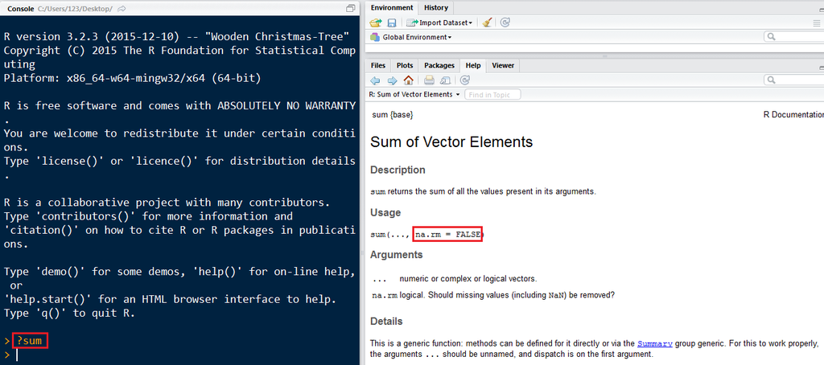

## 其他實用函式

除了敘述統計的函式以外，R裡面還有一些好用的函式，常常會在處理資料時派上用場。  
以下列出個人自認好用的函式，但這裡不會多加解釋。  
若有困惑的話，先閱讀函式的說明文件，再加上自我練習，才能漸漸掌握每個函式的使用：

### 串接：paste(), append()

```r
# paste()：串接字串(把 "Happy"" 和 "White Day"" 兩個字串拼貼起來，sep代表連結字串的符號)
paste("Happy", "White-Day", sep=" ")

# append()：把兩個vector串接起來
b <- c(1,2,3)
c <- c(4,5,6)
append(b, c)
```

```
## [1] "Happy White-Day"
## [1] 1 2 3 4 5 6
```

### 合併：rbind(), cbind()

```r
a <- data.frame(x=c(1,2,3), y=c("Henry", "Lun", "Kevin"))
b <- data.frame(x=c(4,5,6), y=c("Helen", "Tommy", "Leon"))
rbind(a,b) # rbind()：把兩個data frame，依據row合併起來
```

```
##   x     y
## 1 1 Henry
## 2 2   Lun
## 3 3 Kevin
## 4 4 Helen
## 5 5 Tommy
## 6 6  Leon
```

```r
cbind(a,b) # cbind()：把兩個data frame，依據column合併起來
```

```
##   x     y x     y
## 1 1 Henry 4 Helen
## 2 2   Lun 5 Tommy
## 3 3 Kevin 6  Leon
```

### 數列：sample(), seq()

```r
sample(x=1:100, size=10)  # 從1~100數字中，隨機挑10個數字，產生一個數列(vector)
seq(from=1, to=5, by=0.5) # 產生一個「從1開始，每次加0.5，直到5為止」的數列(vector)
```

```
##  [1]  67  40  83 100  17  34   6  98   8  69
## [1] 1.0 1.5 2.0 2.5 3.0 3.5 4.0 4.5 5.0
```

### 預覽：head(), tail()

```r
head(iris, n=6)  # head(): 顯示data frame中的前6筆資料
```

```
##   Sepal.Length Sepal.Width Petal.Length Petal.Width Species
## 1          5.1         3.5          1.4         0.2  setosa
## 2          4.9         3.0          1.4         0.2  setosa
## 3          4.7         3.2          1.3         0.2  setosa
## 4          4.6         3.1          1.5         0.2  setosa
## 5          5.0         3.6          1.4         0.2  setosa
## 6          5.4         3.9          1.7         0.4  setosa
```

```r
tail(iris, n=6)  # tail(): 顯示data frame中的後6筆資料
```

```
##     Sepal.Length Sepal.Width Petal.Length Petal.Width   Species
## 145          6.7         3.3          5.7         2.5 virginica
## 146          6.7         3.0          5.2         2.3 virginica
## 147          6.3         2.5          5.0         1.9 virginica
## 148          6.5         3.0          5.2         2.0 virginica
## 149          6.2         3.4          5.4         2.3 virginica
## 150          5.9         3.0          5.1         1.8 virginica
```

### 排序：order(), sort()

```r
a <- sample(x=1:100, size=10) # 從1~100數字中，隨機挑10個數字，產生一個數列(vector)
a
```

```
##  [1]  2  5 28 70 88 30  7 24 34 21
```

```r
# 用order()，把數列由大排到小；從小排到大，decreasing = FALSE
a[order(a, decreasing=TRUE)]
```

```
##  [1] 88 70 34 30 28 24 21  7  5  2
```

```r
# 和 a[order(a, decreasing=TRUE)] 一樣效果
sort(a, decreasing=TRUE)
```

```
##  [1] 88 70 34 30 28 24 21  7  5  2
```

### 重複：unique(), duplicated()

```r
a <- c("A", "B", "C", "A", "A", "B")
unique(a)       # 萃取資料中unique的element
```

```
## [1] "A" "B" "C"
```

```r
duplicated(a)            # 若後面有重複的資料，函式會回傳TRUE，而第一個資料會是FALSE
a[duplicated(a)==FALSE]  # 和 unique(a)一樣效果
```

```
## [1] FALSE FALSE FALSE  TRUE  TRUE  TRUE
## [1] "A" "B" "C"
```

### which()

```r
# which()：找出第幾個element是TRUE(在a裡面，第幾個element的值等於100)
a <- c(68,73,99,100,56,100,85,36)
which(a==100)
```

```
## [1] 4 6
```

除此之外，網路上有人詳列出[各種好用的函式](http://www3.nccu.edu.tw/~99354011/R%20commands%2811.09.13%29.pdf)的一覽表，當作參考。

# **2. 套件(package)**

基本上，每一個函式都有對應的套件(package)。  
不過你可能會覺得奇怪，當我們在使用上面那些函式時，似乎沒怎麼琢磨在套件上？  
那是因為，R已經將那些套件內建在裡面，因此我們可以直接呼叫(call)這些函式來使用。

現在問題來了，如果我們想使用那些「沒有內建在R裡面」的函式呢？  
例如，我們想要使用一個強大的繪圖函式`ggplot()`：

```r
ggplot(data=CO2)
```

```
## Error in ggplot(data = CO2): 沒有這個函數 "ggplot"
```

結果R跟你說「沒有這個函數」，這代表`ggplot()`函式沒有內建在R裡面。  
因此，你得另外**(1)安裝**對應的套件(package)，並且**(2)匯入到R**裡面才可以！

## (1)安裝套件

我們先求助google大神，看`ggplot()`對應到的套件是哪一個？

[figure not shown]

光看搜尋結果，就會發現對應的套件是**`ggplot2`**。  
不過我們還是點開這個有CRAN字樣的網站：CRAN(Comprehensive R Archive Network)，是R的官方網站之一，裡面收錄了所有經過R官方核可後的函式、以及對應的說明文件，就像這樣：

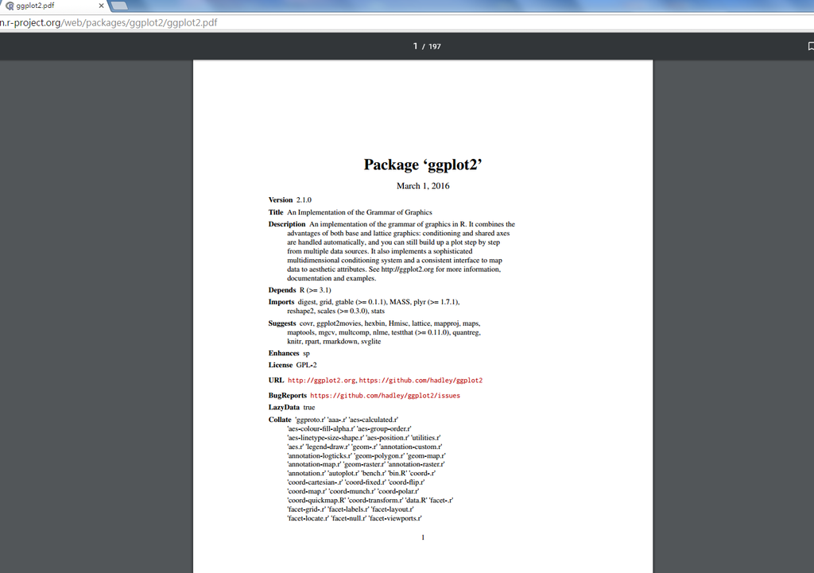

因此，現在我們知道要使用`ggplot()`函式，需要先下載**`ggplot2`**套件。

既然知道套件名稱，那麼就要把套件下載下來，有兩種方式：

## 方法一：用RStudio介面

在RStudio上點開「Tools」->「Install Packages」 ：

[figure not shown]

在中間填入想要安裝的套件名稱，點「Install」就大功告成！

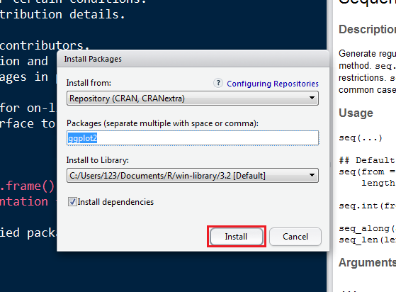

## 方法二：用install.packages()

直接在console裡面輸入函式`install.packages("套件名稱")`！

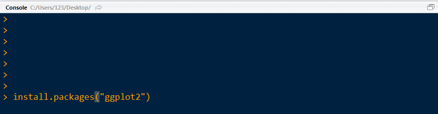

## 匯入套件

當出現這樣的畫面，就代表安裝完成，這代表你已經把R的套件下載到電腦裡面了！

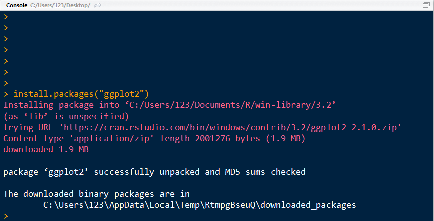

接下來，要使用套件裡面的函式，要將套件匯入到R裡面才可以，  
這時就要用到`library()`/`require()`，用來「匯入套件」的函式：

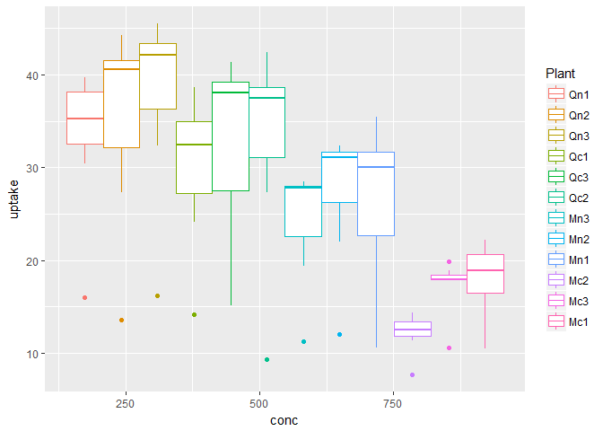

```r
library(ggplot2) #匯入ggplot2套件到R裡面
ggplot(data=CO2) + geom_boxplot(data=CO2,aes(x=conc, y=uptake, colour=Plant))
```

如此一來，就可以順利使用`ggplot()`函式進行繪圖囉～  
(P.S.關於ggplot繪圖的相關細節，會在之後的的筆記中提及，請不用擔心！)

# **總結**

套件和函式是R很重要的功能，但我們不可能記住所有的套件和對應的函式。  
因此，**如何妥善運用google和說明文件**，是在R的學習之路上很重要的一環！

接下來，會進入比較接近「程式設計」的主題：條件式(if-else, switch)、迴圈(for, while)，與函式搭配的情形。  
謝謝大家！  
It’s still a long way to go~

# **(額外) Happy White Day**

今天恰好是3/14，祝大家白色情人節快樂！([R code from here](http://stackoverflow.com/questions/8082429/plot-a-heart-in-r))

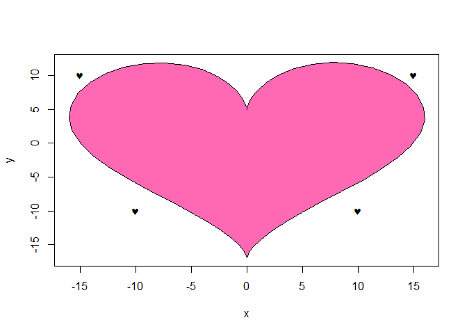

```r
require(graphics)
dat<- data.frame(t=seq(0, 2*pi, by=0.1) )
xhrt <- function(t) 16*sin(t)^3
yhrt <- function(t) 13*cos(t)-5*cos(2*t)-2*cos(3*t)-cos(4*t)
dat$y=yhrt(dat$t)
dat$x=xhrt(dat$t)
with(dat, plot(x,y, type="l"))
with(dat, polygon(x,y, col="hotpink"))
points(c(10,-10, -15, 15), c(-10, -10, 10, 10), pch=169, font=5)
```